# JaleshRFXGBoost

### Assignment - To apply RF and XGBOOST claasifer algo on all the four vectorizers

**Since the data is already preprocessed and saved onto disc, I would be working on the preprocessed data for the given assignment**

```python
#importing required packages

import numpy as np
import pandas as pd
import matplotlib.pyplot as plt
import seaborn as sns
import warnings
import scipy as sc
import sympy
import datetime
#import date
import os
import sys
import graphviz
%matplotlib inline
warnings.filterwarnings('ignore')
```

*importing performance metric libraries*

```python
#importing Logistic regression libraries:
from sklearn.tree import DecisionTreeClassifier

#train test split libaries:
from sklearn.preprocessing import StandardScaler
from sklearn.model_selection import train_test_split

#importing performance libraries:
from sklearn.metrics import f1_score
from sklearn.metrics import confusion_matrix
from sklearn.metrics import precision_score
from sklearn.metrics import precision_recall_curve
from sklearn.metrics import roc_curve
from sklearn.metrics import roc_auc_score
from sklearn.metrics import auc
```

*Imporing preprocessed cleaned data from database file*

```python
%%time
import sqlite3
con = sqlite3.connect('/home/reachjalesh/PreprocessingFolder/final_1L.sqlite')
df = pd.read_sql_query("""select * from reviews""", con)
```

```
CPU times: user 1.21 s, sys: 852 ms, total: 2.06 s
Wall time: 2.06 s
```

```python
len(df)
```

```
100000
```

```python
df.columns
```

```
Index(['index', 'Id', 'ProductId', 'UserId', 'ProfileName',
       'HelpfulnessNumerator', 'HelpfulnessDenominator', 'Score', 'Time',
       'Summary', 'Text', 'CleanedText_Bow', 'ClenedText_W2Vtfdf', 'Bow_feat',
       'Bow_new_feat', 'w2v_feat', 'w2v_new_feat'],
      dtype='object')
```

```python
#op of BoW cleaned text after preprocessing:
df.CleanedText_Bow.head(2)
```

```
0    witti littl book make son laugh loud recit car...
1    rememb see show air televis year ago child sis...
Name: CleanedText_Bow, dtype: object
```

```python
#op of BoW feature engineered text column after preprocessing:
df.Bow_new_feat.head(2)
```

```
0    everi book educ witti littl book make son laug...
1    whole seri great way spend time child rememb s...
Name: Bow_new_feat, dtype: object
```

*sorting dataframe based on time*

```python
#sorting the datframe based on time:
print(len(df))
df = df.sort_values('Time', ascending=True)
print()
df['Time'].head(8)
```

```
100000
```

```
0    939340800
1    940809600
2    944092800
3    944438400
4    946857600
5    947376000
6    948240000
7    948672000
Name: Time, dtype: int64
```

```python
df.Score.value_counts()
```

```
1    87729
0    12271
Name: Score, dtype: int64
```

# 1. RF - BoW

**train test split**

```python
xtrain, xtest, ytrain, ytest = train_test_split(df.CleanedText_Bow, df.Score, test_size=0.2, shuffle=False)
xtr, xcv, ytr, ycv = train_test_split(xtrain, ytrain, test_size=0.2, shuffle=False)
```

*BoW object instantiation*

```python
from sklearn.feature_extraction.text import CountVectorizer

bow_object = CountVectorizer(ngram_range=(1,1))

xtr = bow_object.fit_transform(xtr)
xcv = bow_object.transform(xcv)
xtest = bow_object.transform(xtest)


print(xtr.shape)
print(xcv.shape)
print(xtest.shape)
```

```
(64000, 29812)
(16000, 29812)
(20000, 29812)
```

```python
os.cpu_count()
```

```
1
```

## BoW - RF instance creation on training and CV data

```python
class RandomForest:

    '''building the Random Forest classifier based off hypeparameters no_of_base_models and max_depth of base_models'''

    #instantiating the instance attributes:
    def __init__(self, xtr, ytr, xcv, ycv, maximum_depth=[1, 3, 5, 7, 9, 11, 13, 15], estimators=[5,7,13,9,11,13,15]):
        self.xtr = xtr
        self.ytr = ytr
        self.xcv = xcv
        self.ycv = ycv
        self.estimators = estimators
        self.maximum_depth = maximum_depth

    #creating a method of calling RF classifier:
    def classfier(self, auc_dict_cv={}, auc_dict_tr={}):
        for estimator in self.estimators:
            for depths in self.maximum_depth:
                clf = RandomForestClassifier(max_depth=depths, n_estimators=estimator, oob_score=True)
                print(depths, estimator)
                clf.fit(self.xtr, self.ytr)
                y_pred_cv = clf.predict_proba(self.xcv)

                #performance metric on CV data:
                fpr_cv, tpr_cv, thresholds_cv = roc_curve(ycv, y_pred_cv[:,1])
                auc_val = auc(fpr_cv, tpr_cv)
                auc_dict_cv[auc_val] = [estimator, depths]

                #performance metrics for training data:
                y_pred_tr = clf.predict_proba(self.xtr)
                fpr_tr, tpr_tr, thresholds_tr = roc_curve(ytr, y_pred_tr[:,1])
                auc_val = auc(fpr_tr, tpr_tr)
                auc_dict_tr[auc_val] = [estimator, depths]

        return auc_dict_tr, auc_dict_cv
```

```python
%time
#importing random forest classifier:
from sklearn.ensemble import RandomForestClassifier

BoW_instance = RandomForest(xtr, ytr, xcv, ycv)

dictionary_train, dictionary_cv = BoW_instance.classfier()
```

```
CPU times: user 0 ns, sys: 0 ns, total: 0 ns
Wall time: 6.2 µs
1 5
```

```
3 5
5 5
7 5
9 5
11 5
13 5
15 5
1 7
3 7
5 7
7 7
9 7
11 7
13 7
15 7
```

[output cut: 40 more lines]

```python
train_list = [[np.round(x, 5), y] for x, y in dictionary_train.items()]
cv_list = [[np.round(x, 5), y] for x, y in dictionary_cv.items()]

print(train_list[0])

print()
print(cv_list[0])
```

```
[0.54274, [5, 1]]

[0.55308, [5, 1]]
```

**sorting the data based off AUC score**

```python
tr_list = sorted(train_list, key=lambda x: x[0], reverse=True)
cv_list = sorted(cv_list, key=lambda x: x[0], reverse=True)
print('sorted train list score based off AUC score is:\n', tr_list[0:3])
print('****************************************')
print()
print('sorted CV list score based off AUC score is:\n', cv_list[0:3])
```

```
sorted train list score based off AUC score is:
 [[0.88212, [15, 13]], [0.87603, [15, 15]], [0.87196, [13, 15]]]

sorted CV list score based off AUC score is:
 [[0.85593, [15, 13]], [0.84809, [15, 15]], [0.84443, [13, 15]]]
```

```python
len(tr_list)
```

```
56
```

**creating dataframe for plotting different CV value of AUC , depth and estimator models**

```python
auc_scores = []
no_base_modesl = []
no_depths = []

for i in range(len(cv_list)):
    auc_scores.append(cv_list[i][0])
    no_base_modesl.append(cv_list[i][1][0])
    no_depths.append(cv_list[i][1][1])

df_dict = dict(base_models=no_base_modesl,
              depths=no_depths,
              auc_val=auc_scores)
d_dframe = pd.DataFrame(df_dict)
d_dframe.head(4)
```

|  | auc_val | base_models | depths |
| --- | --- | --- | --- |
| 0 | 0.85593 | 15 | 13 |
| 1 | 0.84809 | 15 | 15 |
| 2 | 0.84443 | 13 | 15 |
| 3 | 0.84274 | 13 | 15 |

**Plotting heatmap of CV data of AUC vs no of base models and depths**

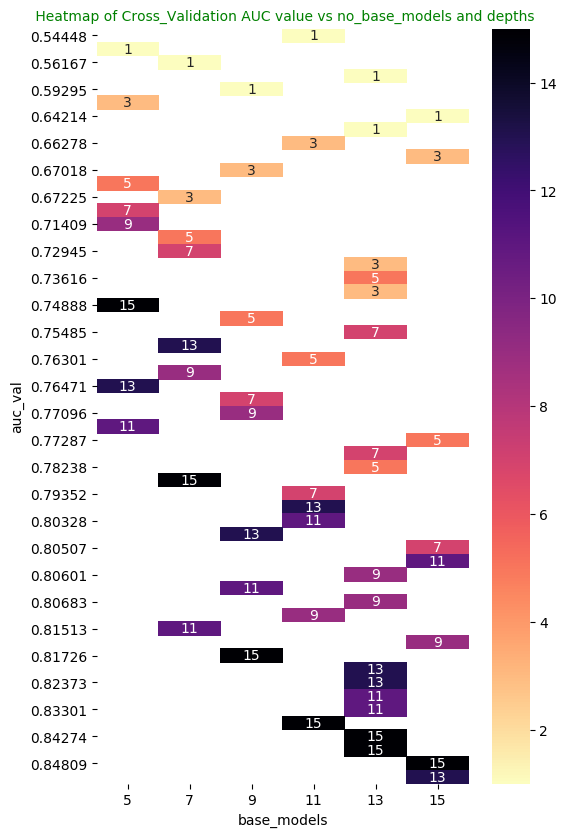

```python
fig = plt.figure(figsize=(6, 10), dpi=100)
d_pivot = d_dframe.pivot('auc_val','base_models', 'depths')
sns.heatmap(d_pivot, annot=True, cmap='magma_r')
plt.title(' Heatmap of Cross_Validation AUC value vs no_base_models and depths', size=10, color='green')
```

*Plotting AUC Curve on training and cv data based off depth*

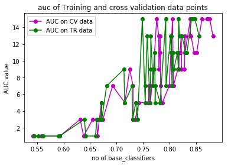

```python
plt.plot([x[0] for x in tr_list], [x[1][1] for x in tr_list], linestyle='-', color='m', marker='o',label='AUC on CV data')
plt.plot([x[0] for x in cv_list], [x[1][1] for x in cv_list], linestyle='-', color='g', marker='o', label='AUC on TR data')
#plt.plot([0, 1], [0, 1], linestyle='--')
plt.xlabel("no of base_classifiers")
plt.ylabel('AUC value')
plt.title('auc of Training and cross validation data points')
plt.legend()
```

### 1. OptimalBoW - RF[depth = 13 and basemodels = 15]

```python
rf = RandomForestClassifier(max_depth=13, n_estimators=15, class_weight='balanced')
rf.fit(xtr, ytr)

#prediction on training data:
y_pred_tr = rf.predict_proba(xtr)
fpr_tr, tpr_tr, thresholds_tr= roc_curve(ytr, y_pred_tr[:,1])
auc_tr = auc(fpr_tr, tpr_tr)

#prediction on test data:
ypred = rf.predict_proba(xtest)
fpr_test, tpr_test, thresholds_test= roc_curve(ytest, ypred[:,1])
auc_test = auc(fpr_test, tpr_test)

print(auc_test)
```

```
0.8435879172089559
```

*plotting confusion matrix on test data*

```
CPU times: user 0 ns, sys: 0 ns, total: 0 ns
Wall time: 6.44 µs
```

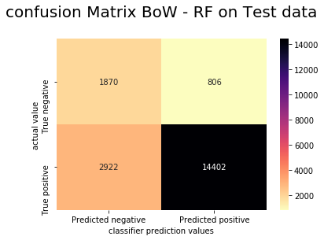

```python
%time
ypred = np.where(ypred[:,1] < 0.5, 0, 1)
#creating confusion matrix:

cf = confusion_matrix(ytest, ypred)
labels = ['True negative', 'True positive']

df_cf = pd.DataFrame(cf, index=labels, columns=['Predicted negative', 'Predicted positive'])
sns.heatmap(df_cf, annot=True,fmt='3d', cmap='magma_r')

plt.title("confusion Matrix BoW - RF on Test data\n", size=20)
plt.xlabel("classifier prediction values")
plt.ylabel("actual value")
plt.show()
```

*plotting confusion matrix on training data*

```
CPU times: user 0 ns, sys: 0 ns, total: 0 ns
Wall time: 6.44 µs
```

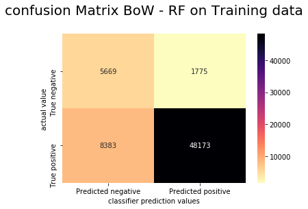

```python
%time
y_pred_tr = np.where(y_pred_tr[:,1] < 0.5, 0, 1)
#creating confusion matrix:

cf = confusion_matrix(ytr, y_pred_tr)
labels = ['True negative', 'True positive']

df_cf = pd.DataFrame(cf, index=labels, columns=['Predicted negative', 'Predicted positive'])
sns.heatmap(df_cf, annot=True,fmt='3d', cmap='magma_r')

plt.title("confusion Matrix BoW - RF on Training data\n", size=20)
plt.xlabel("classifier prediction values")
plt.ylabel("actual value")
plt.show()
```

*plotting ROC curve on test data and training data*

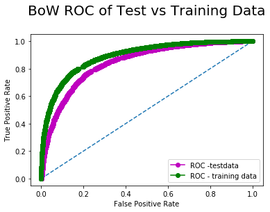

```python
plt.plot(fpr_test, tpr_test, color='m', marker='o',label='ROC -testdata')
plt.plot([0, 1], [0, 1], linestyle='--')
plt.plot(fpr_tr, tpr_tr, linestyle='-', color='g', marker='o', label='ROC - training data')
plt.xlabel('False Positive Rate')
plt.ylabel('True Positive Rate')
plt.title('BoW ROC of Test vs Training Data\n', size=20)
plt.legend()
```

**important features for positive and negative reviews**

```python
features = bow_object.get_feature_names()
featuresAndcoeff = sorted(zip(rf.feature_importances_, features))
top_features = zip(featuresAndcoeff[:25],featuresAndcoeff[:-(25+1): -1] )
print('\t\t\t\tNegative\t\t\t\t\t\t\tPositive')
print('-' * 120)

for (wn1, fn1), (wp1, fp1) in top_features:
    print('{:>20} {:>20}                                {:>20} {:>20}'.format(wn1, fn1, wp1, fp1))
```

```
				Negative							Positive
------------------------------------------------------------------------------------------------------------------------
                 0.0                  aaa                                 0.03720678049914402                  not
                 0.0        aaaaaaaaagghh                                 0.03112867415343571                would
                 0.0               aaaaah                                0.030172031917479716                great
                 0.0 aaaaahhhhhhhhhhhhhhhh                                0.029582446256334893                 best
                 0.0                aaaah                                0.029495845013799534               delici
                 0.0                 aaah                                0.029134259497958122               return
                 0.0               aachen                                0.022993920719890093              perfect
                 0.0                  aad                                 0.02176874081766172                 love
                 0.0                 aadp                                0.021675569005422016                 nice
                 0.0                aafco                                0.016945143540645833                  bad
                 0.0                 aagh                                0.015392929128202207                 wast
                 0.0                  aah                                0.013350576737147544                bland
                 0.0                 aahh                                 0.01308493304703448                 away
                 0.0                 aand                                0.011571253063845707                 keep
                 0.0             aardvark                                0.011350439393212779              compani
                 0.0                   ab                                0.010795778347092416                stale
                 0.0                aback                                0.010739876822661778                 item
                 0.0              abandon                                0.010591538568098522                 poor
                 0.0              abaolut                                0.010173271675200827                 find
                 0.0             abattoir                                0.010151966634456703              thought
                 0.0                 abba                                0.009490147545727004                email
                 0.0                abbey                                0.009024688528102546                guess
                 0.0                 abbi                                0.008851123173408516                thank
                 0.0              abbrevi                                 0.00868018915856111              disgust
                 0.0                  abc                                0.007625183844275655              terribl
```

**since for negative class we are observing many features having feature importance values coming as 0,I m discarding all the features having 0 feature importance values and then printing the output of yop 25 features below:**

```python
features = bow_object.get_feature_names()
featuresAndcoeff = sorted(zip(rf.feature_importances_, features))
l = []
for a, b in featuresAndcoeff:
    if a == 0:
        continue
    else:
        l.append([a,b])

l = sorted(l, key=lambda x: x[0], reverse=True)
positive = l[:25]
negative = l[-(25 + 1): -1]
a = dict(top25_pos=positive,top25_neg=negative)
dataframe = pd.DataFrame(a)
dataframe
```

|  | top25_neg | top25_pos |
| --- | --- | --- |
| 0 | [1.1754936182607552e-06, purina] | [0.03720678049914402, not] |
| 1 | [1.119503755430242e-06, colorado] | [0.03112867415343571, would] |
| 2 | [1.1167861569477255e-06, believ] | [0.030172031917479716, great] |
| 3 | [1.0772362169897143e-06, cartlidg] | [0.029582446256334893, best] |
| 4 | [1.0772362169890502e-06, joke] | [0.029495845013799534, delici] |
| 5 | [1.0551623497611525e-06, pastri] | [0.029134259497958122, return] |
| 6 | [1.0523245516374902e-06, overwhelm] | [0.022993920719890093, perfect] |
| 7 | [1.0477965815791225e-06, fragrant] | [0.02176874081766172, love] |
| 8 | [1.045308670497818e-06, improp] | [0.021675569005422016, nice] |
| 9 | [1.0043092868371666e-06, weird] | [0.016945143540645833, bad] |
| 10 | [9.419596307973705e-07, touch] | [0.015392929128202207, wast] |
| 11 | [8.293828986316791e-07, sheet] | [0.013350576737147544, bland] |
| 12 | [7.389826606651589e-07, tripl] | [0.01308493304703448, away] |
| 13 | [7.315333909514978e-07, blackberri] | [0.011571253063845707, keep] |
| 14 | [7.282259153996223e-07, vine] | [0.011350439393212779, compani] |
| 15 | [5.839064116007434e-07, yellowish] | [0.010795778347092416, stale] |
| 16 | [4.749445100890555e-07, popular] | [0.010739876822661778, item] |
| 17 | [4.3791089427800616e-07, dose] | [0.010591538568098522, poor] |
| 18 | [4.138034720529871e-07, crack] | [0.010173271675200827, find] |
| 19 | [2.7156491466996766e-07, experi] | [0.010151966634456703, thought] |
| 20 | [1.8082748814359065e-07, individualist] | [0.009490147545727004, email] |
| 21 | [1.3922680059819814e-07, whoever] | [0.009024688528102546, guess] |
| 22 | [1.3109020518206562e-07, shall] | [0.008851123173408516, thank] |
| 23 | [1.2936355796734093e-07, ive] | [0.00868018915856111, disgust] |
| 24 | [3.884747368190756e-08, toler] | [0.007625183844275655, terribl] |

## Feature Engineering on BoW

```python
df.columns
```

```
Index(['index', 'Id', 'ProductId', 'UserId', 'ProfileName',
       'HelpfulnessNumerator', 'HelpfulnessDenominator', 'Score', 'Time',
       'Summary', 'Text', 'CleanedText_Bow', 'ClenedText_W2Vtfdf', 'Bow_feat',
       'Bow_new_feat', 'w2v_feat', 'w2v_new_feat'],
      dtype='object')
```

**I will be taking "Bow_new_feat" column as this is the combination of two columns: "Reviews" and 'Summary'**

```python
df.Bow_new_feat.head(2)
```

```
0    everi book educ witti littl book make son laug...
1    whole seri great way spend time child rememb s...
Name: Bow_new_feat, dtype: object
```

**Train CV test split**

```python
xtrain, xtest, ytrain, ytest = train_test_split(df.Bow_new_feat, df.Score, test_size=0.2, shuffle=False)
xtr, xcv, ytr, ycv = train_test_split(xtrain, ytrain, test_size=0.2, shuffle=False)
```

*BoW object instantiation*

```python
bow_object = CountVectorizer(ngram_range=(1,1))

xtr = bow_object.fit_transform(xtr)
xcv = bow_object.transform(xcv)
xtest = bow_object.transform(xtest)


print(xtr.shape)
print(xcv.shape)
print(xtest.shape)
```

```
(64000, 31265)
(16000, 31265)
(20000, 31265)
```

## BoW - RF instance creation on training and CV data

```python
class RandomForest:

    '''building the Random Forest classifier based off hypeparameters no_of_base_models and max_depth of base_models'''

    #instantiating the instance attributes:
    def __init__(self, xtr, ytr, xcv, ycv, maximum_depth=[1, 3, 5, 7, 9, 11, 13, 15], estimators=[5,7,13,9,11,13,15]):
        self.xtr = xtr
        self.ytr = ytr
        self.xcv = xcv
        self.ycv = ycv
        self.estimators = estimators
        self.maximum_depth = maximum_depth

    #creating a method of calling RF classifier:
    def classfier(self, auc_dict_cv={}, auc_dict_tr={}):
        for estimator in self.estimators:
            for depths in self.maximum_depth:
                clf = RandomForestClassifier(max_depth=depths, n_estimators=estimator, oob_score=True)
                print(depths, estimator)
                clf.fit(self.xtr, self.ytr)
                y_pred_cv = clf.predict_proba(self.xcv)

                #performance metric on CV data:
                fpr_cv, tpr_cv, thresholds_cv = roc_curve(ycv, y_pred_cv[:,1])
                auc_val = auc(fpr_cv, tpr_cv)
                auc_dict_cv[auc_val] = [estimator, depths]

                #performance metrics for training data:
                y_pred_tr = clf.predict_proba(self.xtr)
                fpr_tr, tpr_tr, thresholds_tr = roc_curve(ytr, y_pred_tr[:,1])
                auc_val = auc(fpr_tr, tpr_tr)
                auc_dict_tr[auc_val] = [estimator, depths]

        return auc_dict_tr, auc_dict_cv
```

```python
%time
#importing random forest classifier:
from sklearn.ensemble import RandomForestClassifier

BoW_instance = RandomForest(xtr, ytr, xcv, ycv)

dictionary_train, dictionary_cv = BoW_instance.classfier()
```

```
CPU times: user 0 ns, sys: 0 ns, total: 0 ns
Wall time: 6.68 µs
1 5
3 5
5 5
7 5
9 5
11 5
13 5
15 5
1 7
3 7
5 7
7 7
9 7
```

[output cut: 43 more lines]

**sorting the data based off AUC score**

```python
train_list = [[np.round(x, 5), y] for x, y in dictionary_train.items()]
cv_list = [[np.round(x, 5), y] for x, y in dictionary_cv.items()]

print(train_list[0])

print()
print(cv_list[0])

tr_list = sorted(train_list, key=lambda x: x[0], reverse=True)
cv_list = sorted(cv_list, key=lambda x: x[0], reverse=True)
print('sorted train list score based off AUC score is:\n', tr_list[0:3])
print('****************************************')
print()
print('sorted CV list score based off AUC score is:\n', cv_list[0:3])
```

```
[0.57621, [5, 1]]

[0.57413, [5, 1]]
sorted train list score based off AUC score is:
 [[0.89061, [15, 13]], [0.89049, [11, 15]], [0.88402, [13, 15]]]

sorted CV list score based off AUC score is:
 [[0.87443, [15, 13]], [0.86533, [13, 11]], [0.86511, [11, 15]]]
```

**Plotting heatmap of CV data of AUC vs no of base models and depths**

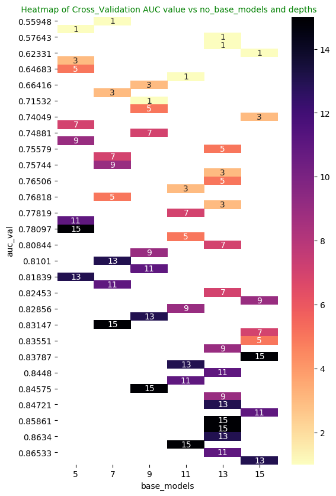

```python
#creating dataframe for pivot table:
auc_scores = []
no_base_modesl = []
no_depths = []

for i in range(len(cv_list)):
    auc_scores.append(cv_list[i][0])
    no_base_modesl.append(cv_list[i][1][0])
    no_depths.append(cv_list[i][1][1])

df_dict = dict(base_models=no_base_modesl,
              depths=no_depths,
              auc_val=auc_scores)
d_dframe = pd.DataFrame(df_dict)
d_dframe.head(4)



#plotting heatmap:
fig = plt.figure(figsize=(6, 10), dpi=100)
d_pivot = d_dframe.pivot('auc_val','base_models', 'depths')
sns.heatmap(d_pivot, annot=True, cmap='magma_r')
plt.title(' Heatmap of Cross_Validation AUC value vs no_base_models and depths', size=10, color='green')
```

*Plotting AUC Curve on training and cv data based off depth*

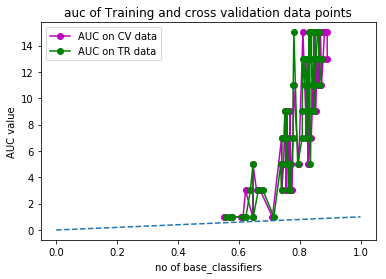

```python
plt.plot([x[0] for x in tr_list], [x[1][1] for x in tr_list], linestyle='-', color='m', marker='o',label='AUC on CV data')
plt.plot([x[0] for x in cv_list], [x[1][1] for x in cv_list], linestyle='-', color='g', marker='o', label='AUC on TR data')
plt.plot([0, 1], [0, 1], linestyle='--')
plt.xlabel("no of base_classifiers")
plt.ylabel('AUC value')
plt.title('auc of Training and cross validation data points')
plt.legend()
```

### 1. OptimalBoW - RF[depth = 13 and basemodels = 15] on Featured enginnering column

```python
rf = RandomForestClassifier(max_depth=13, n_estimators=15, class_weight='balanced')
rf.fit(xtr, ytr)

#prediction on training data:
y_pred_tr = rf.predict_proba(xtr)
fpr_tr, tpr_tr, thresholds_tr= roc_curve(ytr, y_pred_tr[:,1])
auc_tr = auc(fpr_tr, tpr_tr)

#prediction on test data:
ypred = rf.predict_proba(xtest)
fpr_test, tpr_test, thresholds_test= roc_curve(ytest, ypred[:,1])
auc_test = auc(fpr_test, tpr_test)

print(auc_test)
```

```
0.8758911749306889
```

*plotting confusion matrix on test data*

```
CPU times: user 0 ns, sys: 0 ns, total: 0 ns
Wall time: 6.44 µs
```

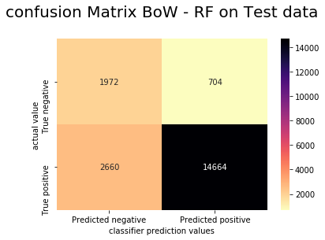

```python
%time
ypred = np.where(ypred[:,1] < 0.5, 0, 1)
#creating confusion matrix:

cf = confusion_matrix(ytest, ypred)
labels = ['True negative', 'True positive']

df_cf = pd.DataFrame(cf, index=labels, columns=['Predicted negative', 'Predicted positive'])
sns.heatmap(df_cf, annot=True,fmt='3d', cmap='magma_r')

plt.title("confusion Matrix BoW - RF on Test data\n", size=20)
plt.xlabel("classifier prediction values")
plt.ylabel("actual value")
plt.show()
```

*plotting confusion matrix on training data*

```
CPU times: user 0 ns, sys: 0 ns, total: 0 ns
Wall time: 6.2 µs
```

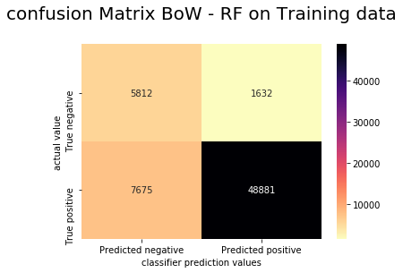

```python
%time
y_pred_tr = np.where(y_pred_tr[:,1] < 0.5, 0, 1)
#creating confusion matrix:

cf = confusion_matrix(ytr, y_pred_tr)
labels = ['True negative', 'True positive']

df_cf = pd.DataFrame(cf, index=labels, columns=['Predicted negative', 'Predicted positive'])
sns.heatmap(df_cf, annot=True,fmt='3d', cmap='magma_r')

plt.title("confusion Matrix BoW - RF on Training data\n", size=20)
plt.xlabel("classifier prediction values")
plt.ylabel("actual value")
plt.show()
```

*plotting ROC curve on test data and training data*

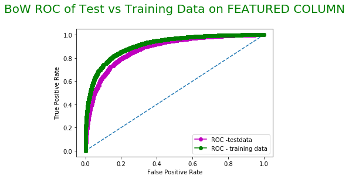

```python
plt.plot(fpr_test, tpr_test, color='m', marker='o',label='ROC -testdata')
plt.plot([0, 1], [0, 1], linestyle='--')
plt.plot(fpr_tr, tpr_tr, linestyle='-', color='g', marker='o', label='ROC - training data')
plt.xlabel('False Positive Rate')
plt.ylabel('True Positive Rate')
plt.title('BoW ROC of Test vs Training Data on FEATURED COLUMN\n', size=20, color='green')
plt.legend()
```

**important features for positive and negative reviews**

```python
features = bow_object.get_feature_names()
featuresAndcoeff = sorted(zip(rf.feature_importances_, features))
top_features = zip(featuresAndcoeff[:25],featuresAndcoeff[:-(25+1): -1] )
print('\t\t\t\tNegative\t\t\t\t\t\t\tPositive')
print('-' * 120)

for (wn1, fn1), (wp1, fp1) in top_features:
    print('{:>20} {:>20}                                {:>20} {:>20}'.format(wn1, fn1, wp1, fp1))
```

```
				Negative							Positive
------------------------------------------------------------------------------------------------------------------------
                 0.0                  aaa                                 0.06171946913594278                  not
                 0.0        aaaaaaaaagghh                                 0.03569732959491379                 love
                 0.0             aaaaaagh                                 0.03316434400192405                 best
                 0.0               aaaaah                                0.027997494494580014                excel
                 0.0 aaaaahhhhhhhhhhhhhhhh                                0.025484348847760237               delici
                 0.0                aaaah                                0.022668263977738138                yummi
                 0.0                 aaah                                 0.02058609958370873                worst
                 0.0               aaamaz                                0.018834190018347272               receiv
                 0.0               aachen                                0.018667256998553945               return
                 0.0                  aad                                0.016198999327574216              terribl
                 0.0                 aadp                                0.014889903786834715              favorit
                 0.0                aafco                                0.014874838059549752                 poor
                 0.0                 aagh                                0.013812739261322572              perfect
                 0.0                  aah                                0.013513446972501652               refund
                 0.0                 aahh                                0.013080160603422014             unfortun
                 0.0                 aand                                0.012393302785014909                 amaz
                 0.0             aardvark                                0.009691136096974832                money
                 0.0                   ab                                 0.00895500410419194              horribl
                 0.0                aback                                0.008002937753678673                 easi
                 0.0               abacor                                0.007932562005754202                 rich
                 0.0               abaloo                                0.007909578643068628            tasteless
                 0.0              abandon                                0.007434017807440536                 nice
                 0.0              abaolut                                 0.00728045775722417              product
                 0.0             abattoir                                0.007001213598140437                 mayb
                 0.0                 abba                                0.006894815255388098               addict
```

**since for negative class we are observing many features having feature importance values coming as 0,I m discarding all the features having 0 feature importance values and then printing the output of yop 25 features below:**

```python
features = bow_object.get_feature_names()
featuresAndcoeff = sorted(zip(rf.feature_importances_, features))
l = []
for a, b in featuresAndcoeff:
    if a == 0:
        continue
    else:
        l.append([a,b])

l = sorted(l, key=lambda x: x[0], reverse=True)
positive = l[:25]
negative = l[-(25 + 1): -1]
a = dict(top25_pos=positive,top25_neg=negative)
dataframe = pd.DataFrame(a)
dataframe
```

|  | top25_neg | top25_pos |
| --- | --- | --- |
| 0 | [9.697001613524187e-07, toast] | [0.06171946913594278, not] |
| 1 | [9.29276549007025e-07, sympathet] | [0.03569732959491379, love] |
| 2 | [8.810536747917336e-07, belief] | [0.03316434400192405, best] |
| 3 | [8.460658424392607e-07, hibiscus] | [0.027997494494580014, excel] |
| 4 | [8.342724579631245e-07, entertain] | [0.025484348847760237, delici] |
| 5 | [7.656045656912377e-07, juevo] | [0.022668263977738138, yummi] |
| 6 | [6.552504081143158e-07, emerg] | [0.02058609958370873, worst] |
| 7 | [6.027780678997406e-07, somehow] | [0.018834190018347272, receiv] |
| 8 | [5.671840499126144e-07, wean] | [0.018667256998553945, return] |
| 9 | [5.655393775697265e-07, reason] | [0.016198999327574216, terribl] |
| 10 | [5.563539746762475e-07, result] | [0.014889903786834715, favorit] |
| 11 | [5.421145810710712e-07, metal] | [0.014874838059549752, poor] |
| 12 | [5.392422477925466e-07, bunch] | [0.013812739261322572, perfect] |
| 13 | [4.851531238317594e-07, issu] | [0.013513446972501652, refund] |
| 14 | [4.3385601923541095e-07, fruit] | [0.013080160603422014, unfortun] |
| 15 | [3.868353513650867e-07, culprit] | [0.012393302785014909, amaz] |
| 16 | [3.791970029871709e-07, roizen] | [0.009691136096974832, money] |
| 17 | [2.7225760654093073e-07, lift] | [0.00895500410419194, horribl] |
| 18 | [2.4578432225365336e-07, tough] | [0.008002937753678673, easi] |
| 19 | [2.2112117016823037e-07, allow] | [0.007932562005754202, rich] |
| 20 | [2.1108405685238384e-07, dinner] | [0.007909578643068628, tasteless] |
| 21 | [6.261921991748851e-08, scarlet] | [0.007434017807440536, nice] |
| 22 | [2.7851871849940903e-08, cartlig] | [0.00728045775722417, product] |
| 23 | [2.711510471379777e-08, sincer] | [0.007001213598140437, mayb] |
| 24 | [9.321469455178233e-09, meat] | [0.006894815255388098, addict] |

# WORDCLOUD on BoW

```python
from wordcloud import WordCloud, STOPWORDS
stop = set(STOPWORDS)
```

[figure not shown]

```
CPU times: user 308 ms, sys: 0 ns, total: 308 ms
Wall time: 312 ms
```

```python
%%time

dataframe['25_Positive_features'] = dataframe.top25_pos.apply(lambda x: x[1])
plt.rcParams['figure.figsize']=(8.0,6.0)
plt.Figure(figsize=(12, 10), dpi=80, facecolor='w', edgecolor='k')
plt.rcParams['font.size']=12                #10
plt.rcParams['savefig.dpi']=100             #72
plt.rcParams['figure.subplot.bottom']=.1

def show_wordcloud(data, title=None):
    wordcloud = WordCloud(background_color='white',stopwords=stop,max_words=25,max_font_size=40,scale=3,
                          random_state=42).generate(str(data))

    fig = plt.figure(1, figsize=(8, 8))
    plt.axis('off')
    if title:
        fig.suptitle(title, fontsize=20)
        fig.subplots_adjust(top=2.3)

    plt.imshow(wordcloud)
    plt.show()

show_wordcloud(dataframe['25_Positive_features'])
#final.loc[final['Score'] >3]['CleanedText_Bow']
```

# TFIDF - Random Forest

```python
#train test split:

xt, xtest, yt, ytest = train_test_split(df.ClenedText_W2Vtfdf, df.Score, test_size=0.2, shuffle=False)
xtr, xcv, ytr, ycv = train_test_split(xt, yt, test_size=0.2, shuffle=False)
```

*tf-Idf featurizer*

```python
from sklearn.feature_extraction.text import TfidfVectorizer

tfidf_object = TfidfVectorizer(ngram_range=(1,1))
xtr = tfidf_object.fit_transform(xtr)
xcv = tfidf_object.transform(xcv)
xtest = tfidf_object.transform(xtest)
```

```python
xtr.shape, xcv.shape, xtest.shape
```

```
((64000, 43852), (16000, 43852), (20000, 43852))
```

**since I HAVE MADE A COMMON CLASS FOR ALL THE VECTORIZERS, USING THAT CLASS in here for instantiating tfidf object**

```python
class RandomForest:

    '''building the Random Forest classifier based off hypeparameters no_of_base_models and max_depth of base_models'''

    #instantiating the instance attributes:
    def __init__(self, xtr, ytr, xcv, ycv, maximum_depth=[1, 3, 5, 7, 9, 11, 13, 15], estimators=[5,7,13,9,11,13,15]):
        self.xtr = xtr
        self.ytr = ytr
        self.xcv = xcv
        self.ycv = ycv
        self.estimators = estimators
        self.maximum_depth = maximum_depth

    #creating a method of calling RF classifier:
    def classfier(self, auc_dict_cv={}, auc_dict_tr={}):
        for estimator in self.estimators:
            for depths in self.maximum_depth:
                clf = RandomForestClassifier(max_depth=depths, n_estimators=estimator, oob_score=True)
                print(depths, estimator)
                clf.fit(self.xtr, self.ytr)
                y_pred_cv = clf.predict_proba(self.xcv)

                #performance metric on CV data:
                fpr_cv, tpr_cv, thresholds_cv = roc_curve(ycv, y_pred_cv[:,1])
                auc_val = auc(fpr_cv, tpr_cv)
                auc_dict_cv[auc_val] = [estimator, depths]

                #performance metrics for training data:
                y_pred_tr = clf.predict_proba(self.xtr)
                fpr_tr, tpr_tr, thresholds_tr = roc_curve(ytr, y_pred_tr[:,1])
                auc_val = auc(fpr_tr, tpr_tr)
                auc_dict_tr[auc_val] = [estimator, depths]

        return auc_dict_tr, auc_dict_cv
```

# TFidf -RF instance creation on training and CV data

```python
import time
start = time.time()
Tfidf_instance = RandomForest(xtr, ytr, xcv, ycv)

dictionary_train, dictionary_cv = Tfidf_instance.classfier()
end = time.time()

print('time is(in seconds): ', end - start)
```

```
1 5
3 5
5 5
7 5
9 5
11 5
13 5
15 5
1 7
3 7
5 7
7 7
9 7
11 7
13 7
```

[output cut: 42 more lines]

**sorting the data based off AUC score**

```python
train_list = [[np.round(x, 5), y] for x, y in dictionary_train.items()]
cv_list = [[np.round(x, 5), y] for x, y in dictionary_cv.items()]

print(train_list[0])

print()
print(cv_list[0])

tr_list = sorted(train_list, key=lambda x: x[0], reverse=True)
cv_list = sorted(cv_list, key=lambda x: x[0], reverse=True)
print('sorted train list score based off AUC score is:\n', tr_list[0:3])
print('****************************************')
print()
print('sorted CV list score based off AUC score is:\n', cv_list[0:3])
```

```
[0.53364, [5, 1]]

[0.53378, [5, 1]]
sorted train list score based off AUC score is:
 [[0.87425, [13, 15]], [0.85715, [13, 13]], [0.85364, [11, 15]]]

sorted CV list score based off AUC score is:
 [[0.83311, [13, 13]], [0.83158, [13, 15]], [0.82396, [15, 11]]]
```

*Plotting AUC Curve on training and cv data based off depth*

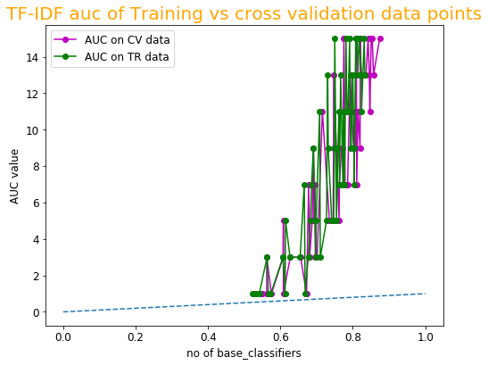

```python
plt.plot([x[0] for x in tr_list], [x[1][1] for x in tr_list], linestyle='-', color='m', marker='o',label='AUC on CV data')
plt.plot([x[0] for x in cv_list], [x[1][1] for x in cv_list], linestyle='-', color='g', marker='o', label='AUC on TR data')
plt.plot([0, 1], [0, 1], linestyle='--')
plt.xlabel("no of base_classifiers")
plt.ylabel('AUC value')
plt.title('TF-IDF auc of Training vs cross validation data points', size=20, color='orange')
plt.legend()
```